# Lab 10b Solutions

Catalina Medina and Vladimir Minin

2022-07-22

```r
library(tidyverse)
library(rcarbon) ## we need this for sliding window averages
library(ggrepel) ## for labeling points with text without much overlap
```

## Adding COVID cases and deaths data

So far we have looked at COVID hospitalization data. Let’s now add cases and deaths to our exploratory analysis of the COVID pandemic in California.

**1** Familiarize yourself with the new dataset.

**1a.** First, download the California cases and deaths data from the [California Open Data Portal] (https://data.ca.gov/dataset/covid-19-time-series-metrics-by-county-and-state).

**1b.** Save the csv file into your lab10 local directory and add it to your github repository.

**1c.** Read the data dictionary that accompanies the data.

**2** Explore time trends

```r
ca_covid_data_og <- read_csv("covid19cases_test.csv")
ca_covid_data <- ca_covid_data_og %>%
  rename(county = area)
```

**2a.** For selected counties (same ones we used in the morning), plot time series of cases per 100,000 people in the county.

```r
ca_five_county_covid_data <- ca_covid_data %>%
  filter(county %in% c("Los Angeles", "Orange", "Sacramento", "Santa Clara", "San Francisco")) %>%
  mutate(county = factor(county))

county_colors <- c(Orange = "#E69F00", Sacramento = "#A857E6",`Los Angeles` = "#0072B2", `Santa Clara` = "#CC79A7", `San Francisco` = "#009E73")

population_scale <- 100000
```

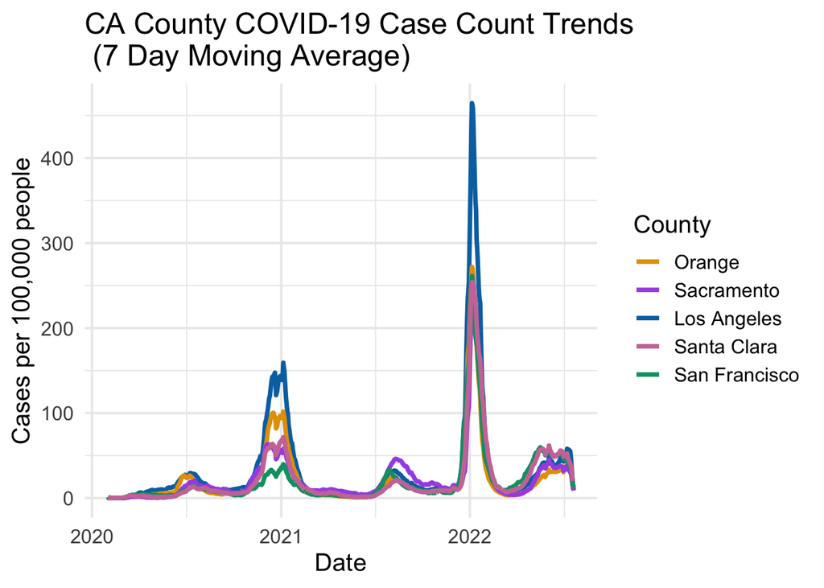

```r
ca_five_county_covid_data <- ca_five_county_covid_data %>%
  mutate(ave_cases = runMean(cases, 7)) %>%
  mutate(scaled_ave_cases = ave_cases / population * population_scale)

ca_five_county_covid_data %>%
  ggplot(aes(x = date, y = scaled_ave_cases, color = county)) +
  geom_line(size = 1.3) +
  scale_color_manual(name = "County", values = county_colors) +
  theme_minimal(base_size = 15) +
  labs(
    x = "Date",
    y = "Cases per 100,000 people"
  ) +
  ggtitle("CA County COVID-19 Case Count Trends \n (7 Day Moving Average)")
```

**2b.** For selected counties (same ones we used in the morning), plot time series of number of tests per 100,000 people in the county.

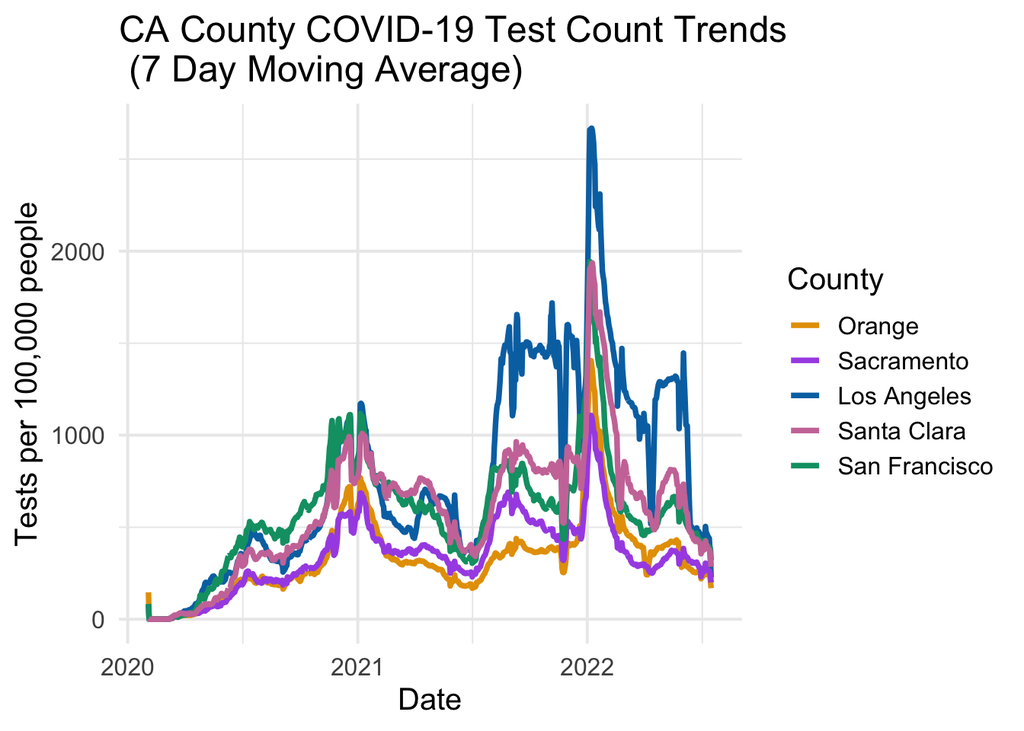

```r
ca_five_county_covid_data <- ca_five_county_covid_data %>%
  mutate(ave_tests = runMean(total_tests, 7)) %>%
  mutate(scaled_ave_tests = ave_tests / population * population_scale)

ca_five_county_covid_data %>%
  ggplot(aes(x = date, y = scaled_ave_tests, color = county)) +
  geom_line(size = 1.3) +
  scale_color_manual(name = "County", values = county_colors) +
  theme_minimal(base_size = 15) +
  labs(
    x = "Date",
    y = "Tests per 100,000 people"
  ) +
  ggtitle("CA County COVID-19 Test Count Trends \n (7 Day Moving Average)")
```

**2c.** For selected counties (same ones we used in the morning), plot time series of number of deaths per 100,000 people in the county.

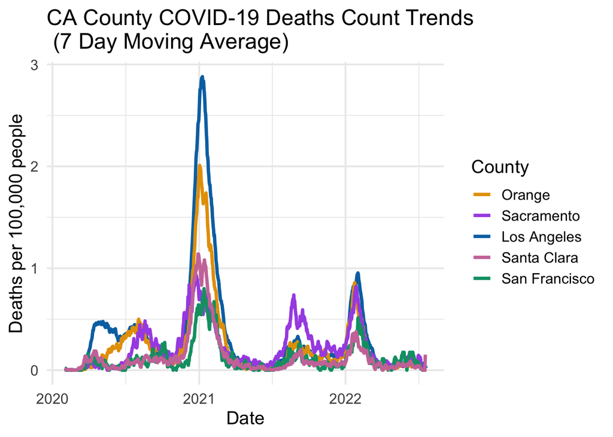

```r
ca_five_county_covid_data <- ca_five_county_covid_data %>%
  mutate(ave_deaths = runMean(deaths, 7)) %>%
  mutate(scaled_ave_deaths = ave_deaths / population * population_scale)

ca_five_county_covid_data %>%
  ggplot(aes(x = date, y = scaled_ave_deaths, color = county)) +
  geom_line(size = 1.3) +
  scale_color_manual(name = "County", values = county_colors) +
  theme_minimal(base_size = 15) +
  labs(
    x = "Date",
    y = "Deaths per 100,000 people"
  ) +
  ggtitle("CA County COVID-19 Deaths Count Trends \n (7 Day Moving Average)")
```

**2d.** For selected counties (same ones we used in the morning), plot time series of test positivity – proportion of positive tests on a given day.

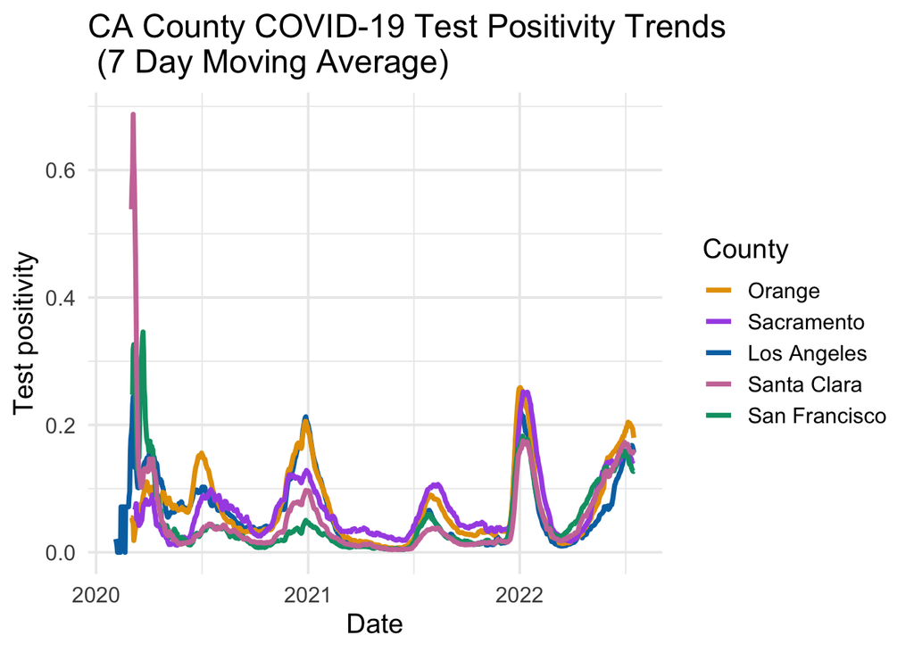

```r
ca_five_county_covid_data <- ca_five_county_covid_data %>%
  mutate(per_pos_tests = positive_tests / total_tests) %>%
  mutate(ave_per_pos_tests = runMean(per_pos_tests, 7))

ca_five_county_covid_data %>%
  ggplot(aes(x = date, y = ave_per_pos_tests, color = county)) +
  geom_line(size = 1.3) +
  scale_color_manual(name = "County", values = county_colors) +
  theme_minimal(base_size = 15) +
  labs(
    x = "Date",
    y = "Test positivity"
  ) +
  ggtitle("CA County COVID-19 Test Positivity Trends \n (7 Day Moving Average)")
```

Note that the recent decrease in positivity could be to delay in reporting of test results.

**3** Explore relationships between COVID data streams/indicators

**3a.** Case-to-fatality-ratio (CFR) is an important epidemiological quantity. It is defined as the total number of deaths divided by the total number of cases over a specified period of time. CFR serves as an upper bound for another important epidemiological unknown – infection-to-fatality ratio (IFR). Create a plot that shows how CFR was changing during the course of the pandemic.

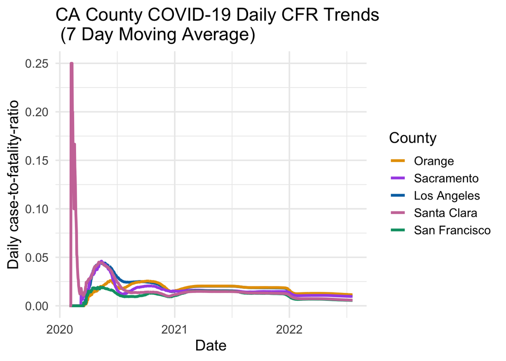

```r
ca_five_county_covid_data <- ca_five_county_covid_data %>%
  mutate(cfr = cumulative_deaths / cumulative_cases) %>%
  mutate(ave_per_pos_tests = runMean(per_pos_tests, 7)) %>%
  mutate(scaled_ave_per_pos_tests = ave_per_pos_tests / population * population_scale)

ca_five_county_covid_data %>%
  ggplot(aes(x = date, y = cfr, color = county)) +
  geom_line(size = 1.3) +
  scale_color_manual(name = "County", values = county_colors) +
  theme_minimal(base_size = 15) +
  labs(
    x = "Date",
    y = "Daily case-to-fatality-ratio"
  ) +
  ggtitle("CA County COVID-19 Daily CFR Trends \n (7 Day Moving Average)")
```

CFR is higher and more variable during early stages of the pandemic because of shortage of testing during that period that lead to infections severely underreported.

**3b.** Plot changes in the case-to-hostpitalization-ratio. Notice that we cannot compute cumulative hospitalization, so we have to compute these ratios on a daily basis. Notice this task requires joining of hospitalization and cases/deaths data. What are potential problems with summarizing the data this way?

```r
hospital_og <- read_csv("covid19hospitalbycounty.csv")

joined_case_hospital <- hospital_og %>%
  rename(date = todays_date) %>%
  select(county, date, hospitalized_covid_confirmed_patients) %>%
  inner_join(ca_five_county_covid_data, by=c("county", "date"))
```

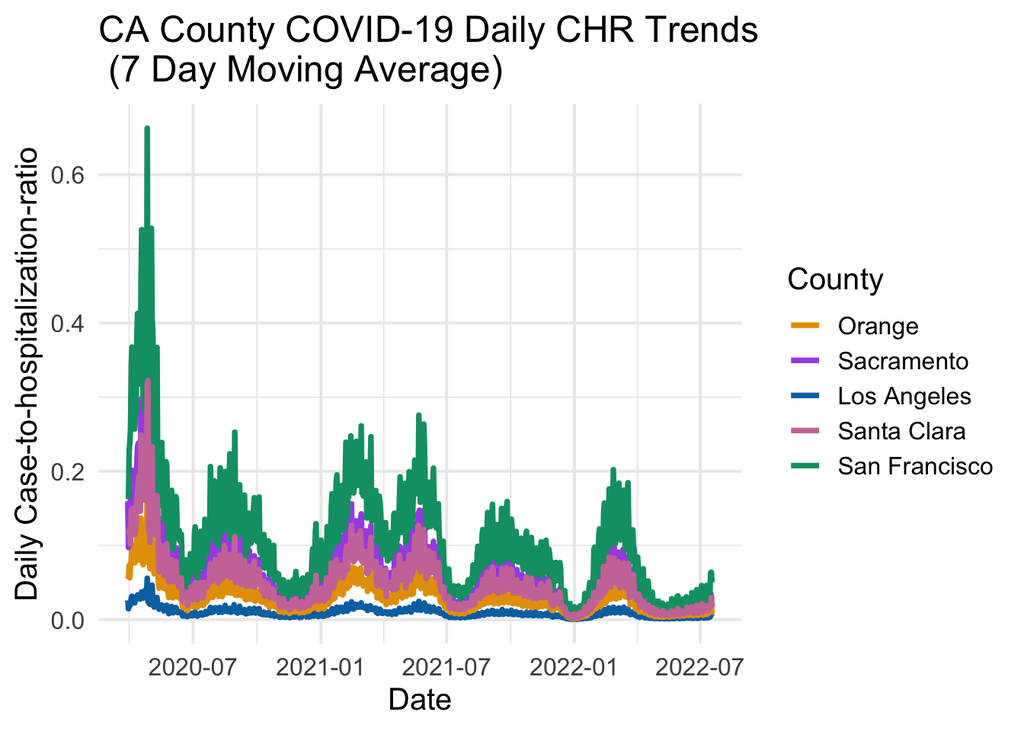

```r
ca_five_county_covid_data <- joined_case_hospital %>%
  mutate(case_to_hosp_ratio = hospitalized_covid_confirmed_patients / cases) %>%
  mutate(ave_case_to_hosp_ratio = runMean(case_to_hosp_ratio, 7)) %>%
  mutate(scaled_ave_case_to_hosp_ratio = ave_case_to_hosp_ratio / population * population_scale)

ca_five_county_covid_data %>%
  ggplot(aes(x = date, y = scaled_ave_case_to_hosp_ratio, color = county)) +
  geom_line(size = 1.3) +
  scale_color_manual(name = "County", values = county_colors) +
  theme_minimal(base_size = 15) +
  labs(
    x = "Date",
    y = "Daily Case-to-hospitalization-ratio"
  ) +
  ggtitle("CA County COVID-19 Daily CHR Trends \n (7 Day Moving Average)")
```

This comparison is problematic because we are implicitly comparing cases and hospitalized patients in the same time periods. However, cases in one time period become hospitalized patients after 5-10 days, so we are comparing two time series that are misaligned with respect to time.

**3c.** Same as 3b, but now plot change of the hospitalization-to-death-ratio.

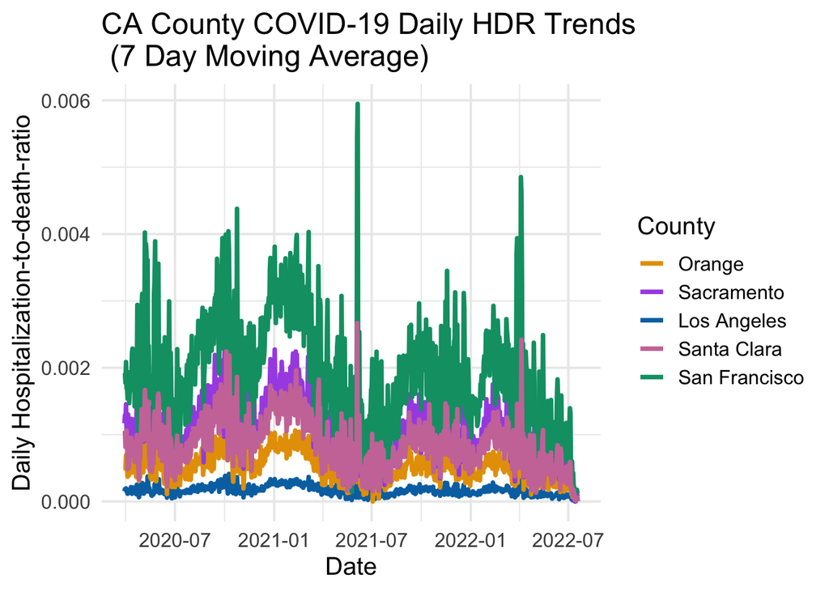

```r
ca_five_county_covid_data <- joined_case_hospital %>%
  mutate(hosp_to_death_ratio = deaths / hospitalized_covid_confirmed_patients) %>%
  mutate(ave_hosp_to_death_ratio = runMean(hosp_to_death_ratio, 7)) %>%
  mutate(scaled_ave_hosp_to_death_ratio = ave_hosp_to_death_ratio / population * population_scale)

ca_five_county_covid_data %>%
  ggplot(aes(x = date, y = scaled_ave_hosp_to_death_ratio, color = county)) +
  geom_line(size = 1.3) +
  scale_color_manual(name = "County", values = county_colors) +
  theme_minimal(base_size = 15) +
  labs(
    x = "Date",
    y = "Daily Hospitalization-to-death-ratio"
  ) +
  ggtitle("CA County COVID-19 Daily HDR Trends \n (7 Day Moving Average)")
```

**3d** Compare cumulative summaries of cases and deaths across all counties over the whole time period.

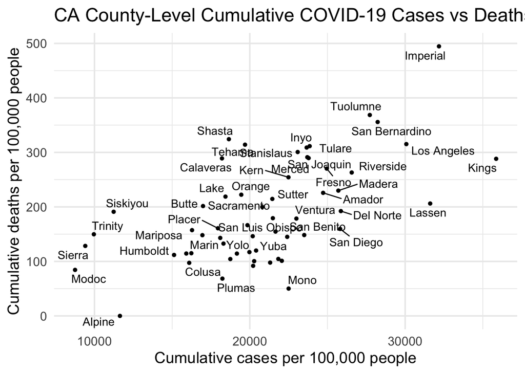

```r
most_recent_date = ca_covid_data %>% summarise(max_date = max(date, na.rm=T))

cumulative_cases_deaths <- ca_covid_data %>% filter(date == most_recent_date & area_type == "County")


cumulative_cases_deaths %>%
  ggplot(aes(x = cumulative_cases/population*100000, y = cumulative_deaths/population*100000)) +
  geom_point(size = 1.3) +
 geom_text_repel(aes(label=county)) +
  theme_minimal(base_size = 15) +
  labs(
    x = "Cumulative cases per 100,000 people",
    y = "Cumulative deaths per 100,000 people"
  ) +
  ggtitle("CA County-Level Cumulative COVID-19 Cases vs Deaths")
```

The relationship between cases and deaths is fairly linear, but the variation is substantial. A very small Alpine county (population size is 1117 people) reported zero deaths due to COVID-19! Even after excluding this county, the range of cumulative deaths per 100,000 people is between 50 and 500, spanning one order of magnitude. The range of cumulative cases per 100,000 people is much smaller. Imperial county number of cumulative deaths stands out as an unusually high.